# R Notebook

Anusha Karunakaran

11/13/2019

# Problem 1

## Problem 1.c

We cannot directly use a parametric test unless we know that the means of the samples follow a normal distribution. We could use a shapiro test to determine with some confidence if the means follow a normal distribution. Based on the result, we can determine whether to use the parametric tests or not.

## Problem 1.d

```
Step 1: Hypotheses

Ho: Mu >= 213
H1: Mu < 213

Step 2: Determine test

T-test!

Step 3: Calculate Test statistic
```

```r
BaseballData <- read.table("C:/Users/anush/Downloads/Coursework/OPIM-5603-Statistics in Business Analytics-SECB13-1198/Homework Solutions/Baseball Games.csv",header = TRUE,sep=",")
Mu0 <- 213
xBar <- mean(BaseballData$Time)
n <- nrow(BaseballData)
SE <- sd(BaseballData$Time)/sqrt(n)
df <- n-1

t.test.statistic <- (xBar - 213) / SE
t.test.statistic
```

```
## [1] -2.542563
```

Step 4: Determine P-value

```r
pt(t.test.statistic, df)
```

```
## [1] 0.01172658
```

## Problem 1.e

```r
# t-test
TS <- (xBar - Mu0) / (SE)
TS
```

```
## [1] -2.542563
```

```r
negative_Zalpha <- -1 * qt(0.99, df)
print(paste("For t-test, ", round(TS,2), "that is lesser than ", round(negative_Zalpha,2), " will lead to rejection of the null hypothesis"))
```

```
## [1] "For t-test,  -2.54 that is lesser than  -2.62  will lead to rejection of the null hypothesis"
```

Fail to reject the null hypothesis, since the P-value = 0.011 is greater than the alpha value of 0.01.

## Problem 1.f

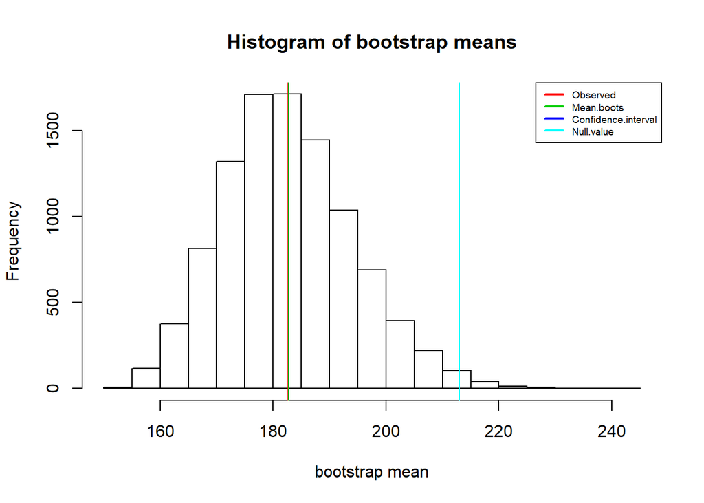

```
##
##
##  RESULTS OF PERCENTILE BOOTSTRAP FOR MEAN
##
##     SUMMARY Variable  n Statistic Observed
##  STATISTICS     Time 15      mean 182.6667
##
##  BOOTSTRAP Replications     Mean       SE  Bias Percent.bias
##    SUMMARY         9999 182.7787 11.58315 0.112       0.0613
##
##  HYPOTHESIS Null Alternative P.value
##        TEST  213   less-than    0.01
##
##  CONFIDENCE Level        Type Confidence.interval
##    INTERVAL   99% upper-bound           213 (UCB)
```

```r
result <- wBoot::boot.one.per(BaseballData$Time, mean, null.hyp = 213, alternative = "less", conf.level =0.99)
result
```

There’s no significant difference in the results.

## Problem 1.g

H0: 80% of our games DO NOT end in 4 hours H1: 80% of our games end in 4 hours

```r
library(wBoot)
```

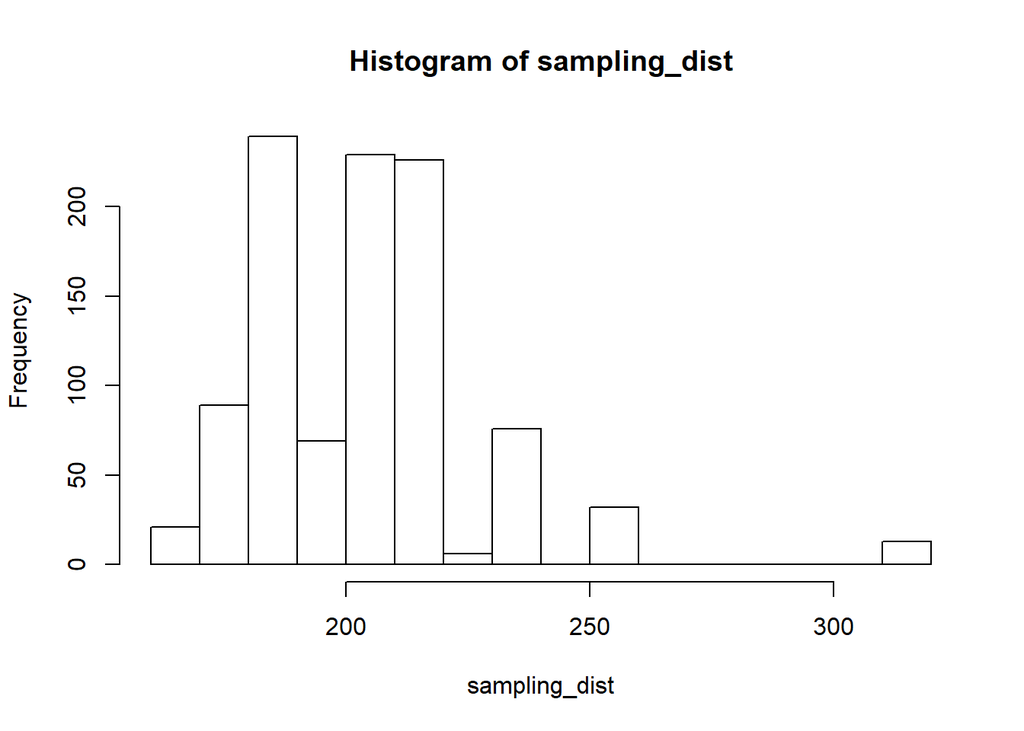

```r
percentile<-quantile(c(BaseballData$Time), probs = 0.8)
sampling_dist <- replicate(1000,quantile(sample(BaseballData$Time,size=length(BaseballData$Time),replace=TRUE),probs = 0.8))
hist(sampling_dist)
```

```r
t.test(sampling_dist, Mu0 = 240 , alternative = "less", conf.level = 0.90)
```

```
##
##  One Sample t-test
##
## data:  sampling_dist
## t = 270.67, df = 999, p-value = 1
## alternative hypothesis: true mean is less than 0
## 90 percent confidence interval:
##      -Inf 204.1547
## sample estimates:
## mean of x
##   203.192
```

```r
t.test(sampling_dist, mu0 = 240 , alternative = "less", conf.level = 0.98)
```

```
##
##  One Sample t-test
##
## data:  sampling_dist
## t = 270.67, df = 999, p-value = 1
## alternative hypothesis: true mean is less than 0
## 98 percent confidence interval:
##      -Inf 204.7358
## sample estimates:
## mean of x
##   203.192
```

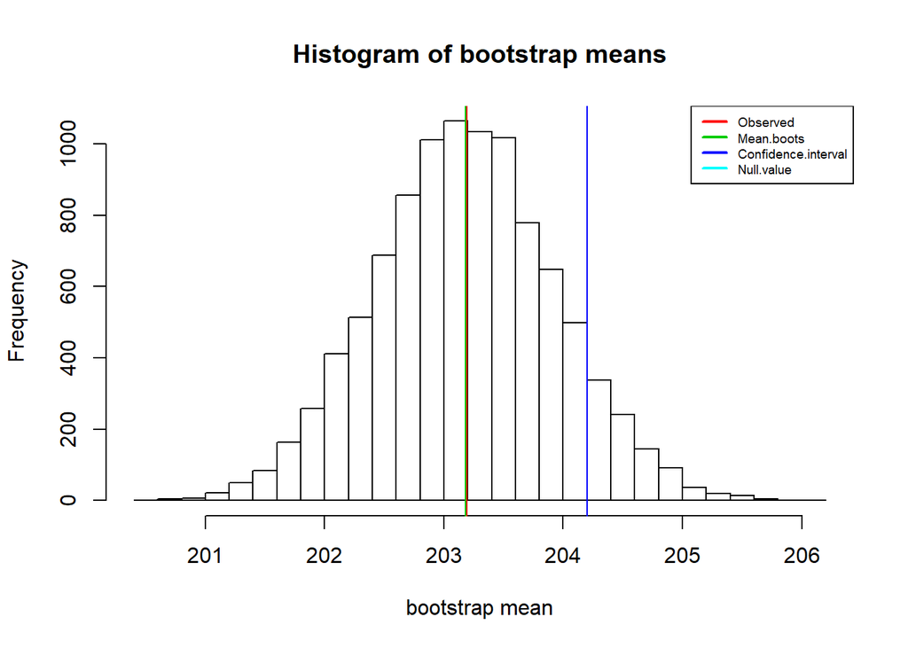

```
##
##
##  RESULTS OF PERCENTILE BOOTSTRAP FOR MEAN
##
##     SUMMARY      Variable    n Statistic Observed
##  STATISTICS sampling_dist 1000      mean  203.192
##
##  BOOTSTRAP Replications     Mean        SE    Bias Percent.bias
##    SUMMARY         9999 203.1796 0.7523714 -0.0124       0.0061
##
##  HYPOTHESIS Null Alternative   P.value
##        TEST  240   less-than P < 0.001
##
##  CONFIDENCE Level        Type Confidence.interval
##    INTERVAL   90% upper-bound         204.2 (UCB)
```

```r
boot.one.per(sampling_dist,mean,null.hyp = 240,alternative = "less",type=NULL,R=9999,conf.level = 0.90)
```

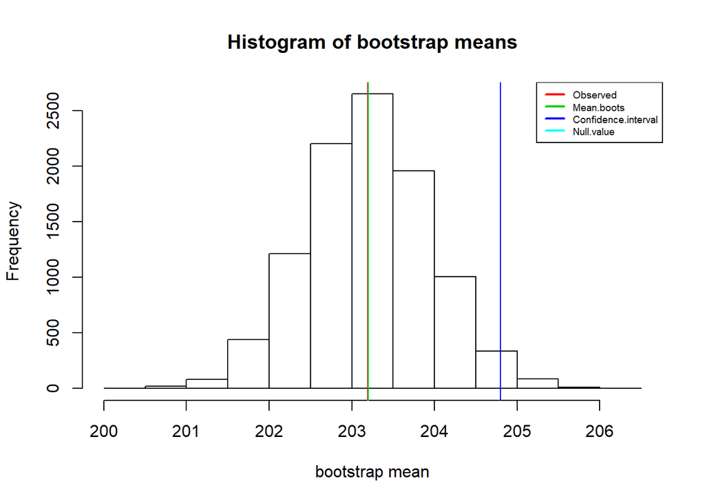

```
##
##
##  RESULTS OF PERCENTILE BOOTSTRAP FOR MEAN
##
##     SUMMARY      Variable    n Statistic Observed
##  STATISTICS sampling_dist 1000      mean  203.192
##
##  BOOTSTRAP Replications     Mean        SE    Bias Percent.bias
##    SUMMARY         9999 203.2006 0.7507753 0.00864      0.00425
##
##  HYPOTHESIS Null Alternative   P.value
##        TEST  240   less-than P < 0.001
##
##  CONFIDENCE Level        Type Confidence.interval
##    INTERVAL   98% upper-bound         204.8 (UCB)
```

```r
boot.one.per(sampling_dist,mean,null.hyp = 240,alternative = "less",type=NULL,R=9999,conf.level = 0.98)
```

# Problem 2

## Problem 2.a

```r
projectTimes <- read.table("C:/Users/anush/Downloads/Coursework/OPIM-5603-Statistics in Business Analytics-SECB13-1198/Homework Solutions/ProjectCompletionTimes.csv",header = TRUE,sep=",")
shapiro.test(projectTimes$Team1CompletionTime)
```

```
##
##  Shapiro-Wilk normality test
##
## data:  projectTimes$Team1CompletionTime
## W = 0.8711, p-value = 0.103
```

```r
t.test(projectTimes$Team1CompletionTime, projectTimes$Team2CompletionTime, paired = FALSE)
```

```
##
##  Welch Two Sample t-test
##
## data:  projectTimes$Team1CompletionTime and projectTimes$Team2CompletionTime
## t = -1.2871, df = 19.874, p-value = 0.2128
## alternative hypothesis: true difference in means is not equal to 0
## 95 percent confidence interval:
##  -23.591681   5.591681
## sample estimates:
## mean of x mean of y
##      76.2      85.2
```

[output not shown]

## Problem 2.b

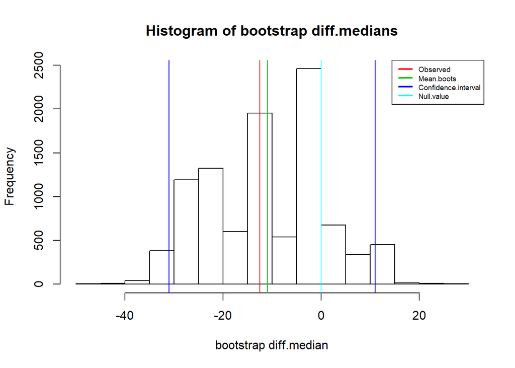

```
##
##
##  RESULTS OF PERCENTILE BOOTSTRAP FOR DIFF.MEDIAN
##
##     SUMMARY        Pop.1               Pop.2 n.1 n.2   Statistic Observed
##  STATISTICS projectTimes Team2CompletionTime  10  15 diff.median    -12.5
##
##  BOOTSTRAP Replications      Mean       SE Bias Percent.bias
##    SUMMARY         9999 -10.91339 12.13692 1.59         12.7
##
##  HYPOTHESIS Null Alternative P.value
##        TEST    0   not-equal   0.323
##
##  CONFIDENCE Level      Type Confidence.interval
##    INTERVAL   95% two-sided           (-31, 11)
```

[output not shown]

```r
library(wBoot)
boot.two.per(na.omit(projectTimes$Team1CompletionTime), projectTimes$Team2CompletionTime, median, null.hyp = 0, stacked = FALSE)
```

## Problem 2.c

Variance test requires that both the samples to be normally distributed. Therefore, run the shapiro test on both the samples.

```r
shapiro.test(projectTimes$Team1CompletionTime)
```

```
##
##  Shapiro-Wilk normality test
##
## data:  projectTimes$Team1CompletionTime
## W = 0.8711, p-value = 0.103
```

```r
shapiro.test(projectTimes$Team2CompletionTime)
```

```
##
##  Shapiro-Wilk normality test
##
## data:  projectTimes$Team2CompletionTime
## W = 0.92777, p-value = 0.2526
```

Clearly, we fail to reject the null hypothesis which means that both the variables follow normal distribution.

```r
var.test(na.omit(projectTimes$Team1CompletionTime), projectTimes$Team2CompletionTime)
```

```
##
##  F test to compare two variances
##
## data:  na.omit(projectTimes$Team1CompletionTime) and projectTimes$Team2CompletionTime
## F = 0.93923, num df = 9, denom df = 14, p-value = 0.9546
## alternative hypothesis: true ratio of variances is not equal to 1
## 95 percent confidence interval:
##  0.2926591 3.5671543
## sample estimates:
## ratio of variances
##          0.9392309
```

```
Is there statistical evidence to conclude that the ratio of the variance of the completion times
for projects for the teams of each of the employees is different? - NO
Failed to reject the null hypothesis  since the true ratio of variances of the completion times is equal to 1
```

# Problem 3

An engineer measured the Brinell hardness of 25 pieces of ductile iron that were subcritically annealed.The engineer hypothesized that the mean Brinell hardness of all such ductile iron pieces is greater than 170. Therefore, he was interested in testing the hypotheses:

H0 : μ = 170 H1: μ > 170

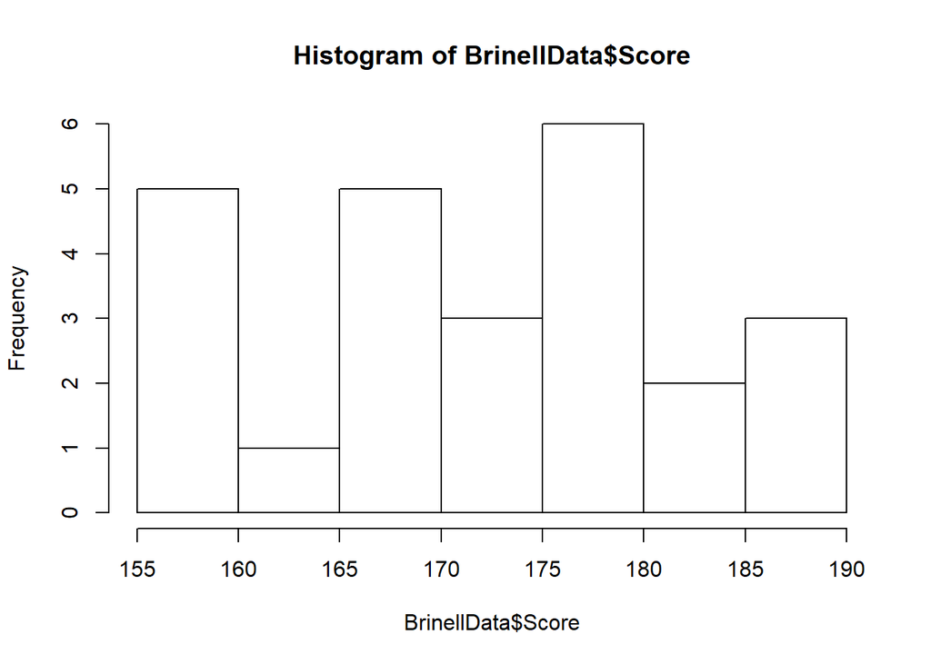

```r
BrinellData <- read.table("C:/Users/anush/Downloads/Coursework/OPIM-5603-Statistics in Business Analytics-SECB13-1198/Homework Solutions/Brinell Hardness.csv",header = TRUE,sep=",")
hist(BrinellData$Score)
```

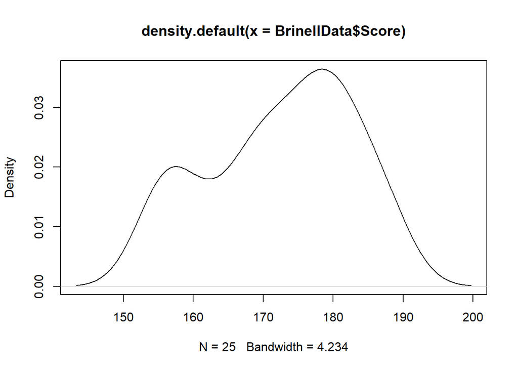

```r
Density <- density(BrinellData$Score)
plot(Density)
```

```r
Mu0 <- 170
xBar <- mean(BrinellData$Score)
xBar
```

```
## [1] 172.52
```

```r
n <- nrow(BrinellData)
n
```

```
## [1] 25
```

```r
SE <- sd(BrinellData$Score)/sqrt(n)
SE
```

```
## [1] 2.062458
```

```r
df <- n

t.test.statistic <- (xBar - 170) / SE
t.test.statistic
```

```
## [1] 1.221843
```

```r
#p value
pt(t.test.statistic, df)
```

```
## [1] 0.8834183
```

Since the P-value, 0.883, is greater than = 0.05, the engineer fails to reject the null hypothesis.

Since the engineer’s test statistic, t* = 1.22, is not greater than 1.7109, the engineer fails to reject the null hypothesis. That is, the test statistic does not fall in the “critical region.” There is insufficient evidence, at the = 0.05 level, to conclude that the mean Brinell hardness of all such ductile iron pieces is greater than 170.